# Multiple Time Series on Ride Hailing Data

Dicky Prigara

July 14, 2021

## Import Library

```r
library(forecast)
library(lubridate)
library(magrittr)
library(tidyverse)
library(tidymodels)
library(padr)
library(MLmetrics)
```

## Import Data

```r
df <- read.csv("C:/Users/user/Downloads/Algoritma/Capstone-ML/data/data-train.csv")
head(df)
```

```
##                         id                  trip_id                driver_id
## 1 59d005e1ffcfa261708ce9cd 59d005e9cb564761a8fe5d3e 59a892c5568be44b2734f276
## 2 59d0066affcfa261708ceb11                     <NA>                     <NA>
## 3 59d006a1ffcfa261708ceba4 59d006c131e39c618969343d 599dc0dfa5b4fd5471ad8453
## 4 59d006d8cb564761a8fe5efd 59d007193d32b861760d4a77 59a5856573d56e7103b5d51d
## 5 59d0073ecb564761a8fe5fdc                     <NA>                     <NA>
## 6 59d007c3ffcfa261708ceee1 59d007de31e39c618969354f 599dc0dfa5b4fd5471ad8453
##                   rider_id           start_time  src_lat  src_lon src_area
## 1 59ad2d6efba75a581666b506 2017-10-01T00:00:17Z 41.07047 29.01945     sxk9
## 2 59cd704bcf482f6ce2fadfdb 2017-10-01T00:02:34Z 41.07487 28.99528     sxk9
## 3 59bd62cc7e3c3b663924ba86 2017-10-01T00:03:29Z 41.04995 29.03107     sxk9
## 4 59c17cd1f6da2d274e16d0a7 2017-10-01T00:04:24Z 41.05287 28.99522     sxk9
## 5 596f47a8a294a82ea3e90e77 2017-10-01T00:06:06Z 41.06760 28.98827     sxk9
## 6 59bd62cc7e3c3b663924ba86 2017-10-01T00:08:19Z 41.04995 29.03107     sxk9
##   src_sub_area dest_lat dest_lon dest_area dest_sub_area  distance    status
## 1        sxk9s 41.11716 29.03650      sxk9         sxk9u  5.379250 confirmed
## 2        sxk9e 41.08351 29.00228      sxk9         sxk9e  1.126098 nodrivers
## 3        sxk9s 41.04495 28.98192      sxk9         sxk9e  4.169492 confirmed
## 4        sxk9e 41.08140 28.98197      sxk9         sxk9e  3.358296 confirmed
## 5        sxk9e 41.02125 29.11316      sxk9         sxk9q 11.693573 nodrivers
## 6        sxk9s 41.04495 28.98192      sxk9         sxk9e  4.169492 confirmed
##   confirmed_time_sec
## 1                  8
## 2                  0
## 3                 32
## 4                 65
## 5                  0
## 6                 27
```

## Check Missing Value

```r
anyNA(df)
```

```
## [1] TRUE
```

```r
colSums(is.na(df))
```

```
##                 id            trip_id          driver_id           rider_id
##                  0               4676               4676                  0
##         start_time            src_lat            src_lon           src_area
##                  0                  0                  0                  0
##       src_sub_area           dest_lat           dest_lon          dest_area
##                  0                  0                  0                  0
##      dest_sub_area           distance             status confirmed_time_sec
##                  0                  0                  0                  0
```

Karena missing value hanya berasal dari coloumn id, maka bisa kita drop karena tidak akan digunakan

## Data Preprocessing

Pertama kita akan ubah tipe data menjadi datetime

```r
df[,"start_time"]<- as_datetime(df[,"start_time"])
```

waktu akan dibulatkan menjadi satuan jam kebelakang

```r
df[,"start_time"]<- floor_date(df[,"start_time"],unit = "hour")
```

kita akan menghitung demand setiap sub area berdasarkan pesanan yang masuk

```r
df_clean<- df %>%select(-c(rider_id,trip_id,driver_id,id)) %>%
  group_by(src_sub_area) %>%
  count(start_time)
```

```r
data_test <- read.csv("C:/Users/user/Downloads/Algoritma/Capstone-ML/data/data-test.csv")
```

karena tidak setiap jam ada pesanan yang masuk, maka ada data yang kosong, dalam time series kita harus mengisi data kosong tersebut menggunakan padding dan mengganti nilai `NA` dengan 0.

```r
df_clean<- df_clean %>% pad()
df_clean$n<- df_clean$n %>% replace_na(0)
```

lalu kita akan lihat pola time series yang terbentuk seperti apa.

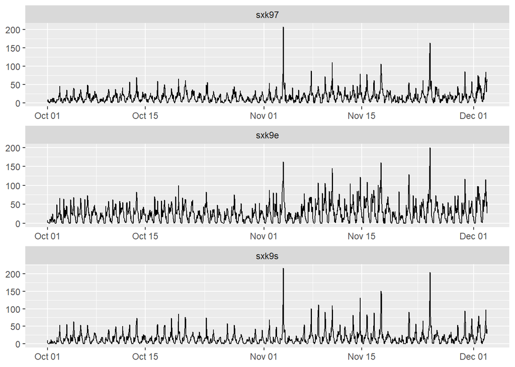

```r
df_clean %>%
  filter(start_time >= max(start_time) - hours(24 * 7 * 9)) %>%
    ggplot(aes(x = start_time, y = n)) +
    geom_line() +
    labs(x = NULL, y = NULL) +
    facet_wrap(~ src_sub_area, scale = "free", ncol = 1)
```

dilihat dari pola timeseries yang terbentuk adalah additive, yaitu pola dan seasonalnya cenderung konstan.

## Cross-Validation

kita akan membagi dataset menjadi train-test dengan metode cross-validation. ukuran train size adalah 9 minggu, dan ukuran test size adalah 1 minggu

```r
test_size <- 24 * 7
train_size <- 24 * 7 * 9

# get the min-max of the time index for each sample
test_end <- max(df_clean$start_time)
test_start <- test_end - hours(test_size) + hours(1)

train_end <- test_start - hours(1)
train_start <- train_end - hours(train_size) + hours(1)
```

```r
intrain <- interval(train_start, train_end)
intest <- interval(test_start, test_end)

intrain
```

```
## [1] 2017-09-24 UTC--2017-11-25 23:00:00 UTC
```

[output not shown]

```r
intest
```

```
## [1] 2017-11-26 UTC--2017-12-02 23:00:00 UTC
```

kita akan melihat plot pembagian antara train dan test dari dataset

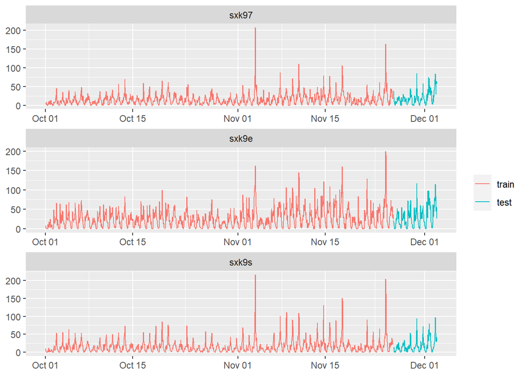

```r
df_clean %>%
  mutate(sample = case_when(
    start_time %within% intrain ~ "train",
    start_time %within% intest ~ "test"
  ))%>% mutate(sample = factor(sample, levels = c("train", "test"))) %>%
  ggplot(aes(x = start_time, y = n, colour = sample)) +
    geom_line() +
    labs(x = NULL, y = NULL, colour = NULL) +
    facet_wrap(~ src_sub_area, scale = "free", ncol = 1)
```

```r
df_clean%<>%
  spread(src_sub_area, n)
df_clean
```

```
## # A tibble: 1,512 x 4
##    start_time          sxk97 sxk9e sxk9s
##    <dttm>              <dbl> <dbl> <dbl>
##  1 2017-10-01 00:00:00     6     8    10
##  2 2017-10-01 01:00:00     4     2     3
##  3 2017-10-01 02:00:00     9     3     1
##  4 2017-10-01 03:00:00     2     2     0
##  5 2017-10-01 04:00:00     5     1     0
##  6 2017-10-01 05:00:00     4     2     0
##  7 2017-10-01 06:00:00     1     1     0
##  8 2017-10-01 07:00:00     0     0     1
##  9 2017-10-01 08:00:00     3     2     5
## 10 2017-10-01 09:00:00     3    11     5
## # ... with 1,502 more rows
```

```r
rec <- recipe(~ ., filter(df_clean, start_time %within% intrain)) %>%
  step_sqrt(all_numeric()) %>%
  step_center(all_numeric()) %>%
  step_scale(all_numeric()) %>%
  prep()

# preview the bake results
df_clean <- bake(rec, df_clean)
df_clean
```

```
## # A tibble: 1,512 x 4
##    start_time           sxk97  sxk9e  sxk9s
##    <dttm>               <dbl>  <dbl>  <dbl>
##  1 2017-10-01 00:00:00 -0.594 -0.697 -0.111
##  2 2017-10-01 01:00:00 -0.841 -1.28  -0.780
##  3 2017-10-01 02:00:00 -0.291 -1.15  -1.12
##  4 2017-10-01 03:00:00 -1.16  -1.28  -1.59
##  5 2017-10-01 04:00:00 -0.711 -1.44  -1.59
##  6 2017-10-01 05:00:00 -0.841 -1.28  -1.59
##  7 2017-10-01 06:00:00 -1.39  -1.44  -1.59
##  8 2017-10-01 07:00:00 -1.94  -1.85  -1.12
##  9 2017-10-01 08:00:00 -0.989 -1.28  -0.544
## 10 2017-10-01 09:00:00 -0.989 -0.497 -0.544
## # ... with 1,502 more rows
```

Kita akan membuat revert back function untuk mengubah tipe data seperti semula.

```r
rec_revert <- function(vector, rec, varname) {

  # store recipe values
  rec_center <- rec$steps[[2]]$means[varname]
  rec_scale <- rec$steps[[3]]$sds[varname]

  # convert back based on the recipe
  results <- (vector * rec_scale + rec_center) ^ 2

  # add additional adjustment if necessary
  results <- round(results)

  # return the results
  results

}
```

sekarang kita memiliki data dengan long format.

```r
df_clean %<>%
  gather(src_sub_area, n, -start_time)
df_clean
```

```
## # A tibble: 4,536 x 3
##    start_time          src_sub_area      n
##    <dttm>              <chr>         <dbl>
##  1 2017-10-01 00:00:00 sxk97        -0.594
##  2 2017-10-01 01:00:00 sxk97        -0.841
##  3 2017-10-01 02:00:00 sxk97        -0.291
##  4 2017-10-01 03:00:00 sxk97        -1.16
##  5 2017-10-01 04:00:00 sxk97        -0.711
##  6 2017-10-01 05:00:00 sxk97        -0.841
##  7 2017-10-01 06:00:00 sxk97        -1.39
##  8 2017-10-01 07:00:00 sxk97        -1.94
##  9 2017-10-01 08:00:00 sxk97        -0.989
## 10 2017-10-01 09:00:00 sxk97        -0.989
## # ... with 4,526 more rows
```

## Modeling

Kita akan mempersiapkan sample indicator untuk membuat nested tabel.

```r
df_clean %<>%
  mutate(sample = case_when(
    start_time %within% intrain ~ "train",
    start_time %within% intest ~ "test"
  )) %>% drop_na()
df_clean
```

```
## # A tibble: 4,536 x 4
##    start_time          src_sub_area      n sample
##    <dttm>              <chr>         <dbl> <chr>
##  1 2017-10-01 00:00:00 sxk97        -0.594 train
##  2 2017-10-01 01:00:00 sxk97        -0.841 train
##  3 2017-10-01 02:00:00 sxk97        -0.291 train
##  4 2017-10-01 03:00:00 sxk97        -1.16  train
##  5 2017-10-01 04:00:00 sxk97        -0.711 train
##  6 2017-10-01 05:00:00 sxk97        -0.841 train
##  7 2017-10-01 06:00:00 sxk97        -1.39  train
##  8 2017-10-01 07:00:00 sxk97        -1.94  train
##  9 2017-10-01 08:00:00 sxk97        -0.989 train
## 10 2017-10-01 09:00:00 sxk97        -0.989 train
## # ... with 4,526 more rows
```

disini kita mulai untuk nest data sub area dan sample yang telah dibuat

```r
df_clean %<>%
  group_by(src_sub_area, sample) %>%
  nest(.key = "data") %>%
  spread(sample, data)
df_clean
```

```
## # A tibble: 3 x 3
## # Groups:   src_sub_area [3]
##   src_sub_area test               train
##   <chr>        <list>             <list>
## 1 sxk97        <tibble [168 x 2]> <tibble [1,344 x 2]>
## 2 sxk9e        <tibble [168 x 2]> <tibble [1,344 x 2]>
## 3 sxk9s        <tibble [168 x 2]> <tibble [1,344 x 2]>
```

## Preparing The Data Model List

kita akan membuat objek time series dengan daily seasonality dan multiple time series dengan daily dan weekly seasonality.

```r
data_funs <- list(
  ts = function(x) ts(x$n, frequency = 24),
  msts = function(x) msts(x$n, seasonal.periods = c(24, 24 * 7))
)
```

disini kita akan convert list menjadi tabel. kita akan memberika sebuah key yaitu `src_sub_area` agar bisa menggabungkan dengan `left_join` nantinya.

```r
data_funs %<>%
  rep(length(unique(df_clean$src_sub_area))) %>%
  enframe("data_fun_name", "data_fun") %>%
  mutate(src_sub_area =
    sort(rep(unique(df_clean$src_sub_area), length(unique(.$data_fun_name))))
  )
```

join nested function dengan nested data.

```r
df_clean%<>%
  left_join(data_funs)
df_clean
```

```
## # A tibble: 6 x 5
## # Groups:   src_sub_area [3]
##   src_sub_area test               train                data_fun_name data_fun
##   <chr>        <list>             <list>               <chr>         <list>
## 1 sxk97        <tibble [168 x 2]> <tibble [1,344 x 2]> ts            <fn>
## 2 sxk97        <tibble [168 x 2]> <tibble [1,344 x 2]> msts          <fn>
## 3 sxk9e        <tibble [168 x 2]> <tibble [1,344 x 2]> ts            <fn>
## 4 sxk9e        <tibble [168 x 2]> <tibble [1,344 x 2]> msts          <fn>
## 5 sxk9s        <tibble [168 x 2]> <tibble [1,344 x 2]> ts            <fn>
## 6 sxk9s        <tibble [168 x 2]> <tibble [1,344 x 2]> msts          <fn>
```

## Preparing Time Series Model

model time series yang akan digunakan `auto.arima` , `ets` , `stlm` , dan `tbats`. Kita akan membuat sebuah fungsi untuk memanggil dan menyimpan model kedalam list.

```r
models <- list(
  auto.arima = function(x) auto.arima(x),
  ets = function(x) ets(x),
  stlm = function(x) stlm(x),
  tbats = function(x) tbats(x, use.box.cox = FALSE)
)
```

ubah menjadi nested format seperti sebelumnya.

```r
models %<>%
  rep(length(unique(df_clean$src_sub_area))) %>%
  enframe("model_name", "model") %>%
  mutate(src_sub_area =
    sort(rep(unique(df_clean$src_sub_area), length(unique(.$model_name))))
  )
models
```

```
## # A tibble: 12 x 3
##    model_name model  src_sub_area
##    <chr>      <list> <chr>
##  1 auto.arima <fn>   sxk97
##  2 ets        <fn>   sxk97
##  3 stlm       <fn>   sxk97
##  4 tbats      <fn>   sxk97
##  5 auto.arima <fn>   sxk9e
##  6 ets        <fn>   sxk9e
##  7 stlm       <fn>   sxk9e
##  8 tbats      <fn>   sxk9e
##  9 auto.arima <fn>   sxk9s
## 10 ets        <fn>   sxk9s
## 11 stlm       <fn>   sxk9s
## 12 tbats      <fn>   sxk9s
```

gunakan `left_join` untuk menggabungkan hasil dengan nested data. Lalu kita akan memfilter `ets` dan `auto.arima` karena kurang cocok untuk digunakan pada multiple time-series.

```r
df_clean %<>%
  left_join(models) %>%
  filter(
    !(model_name == "ets" & data_fun_name == "msts"),
    !(model_name == "auto.arima" & data_fun_name == "msts")
  )
df_clean
```

```
## # A tibble: 18 x 7
## # Groups:   src_sub_area [3]
##    src_sub_area test        train        data_fun_name data_fun model_name model
##    <chr>        <list>      <list>       <chr>         <list>   <chr>      <lis>
##  1 sxk97        <tibble [1~ <tibble [1,~ ts            <fn>     auto.arima <fn>
##  2 sxk97        <tibble [1~ <tibble [1,~ ts            <fn>     ets        <fn>
##  3 sxk97        <tibble [1~ <tibble [1,~ ts            <fn>     stlm       <fn>
##  4 sxk97        <tibble [1~ <tibble [1,~ ts            <fn>     tbats      <fn>
##  5 sxk97        <tibble [1~ <tibble [1,~ msts          <fn>     stlm       <fn>
##  6 sxk97        <tibble [1~ <tibble [1,~ msts          <fn>     tbats      <fn>
##  7 sxk9e        <tibble [1~ <tibble [1,~ ts            <fn>     auto.arima <fn>
##  8 sxk9e        <tibble [1~ <tibble [1,~ ts            <fn>     ets        <fn>
##  9 sxk9e        <tibble [1~ <tibble [1,~ ts            <fn>     stlm       <fn>
## 10 sxk9e        <tibble [1~ <tibble [1,~ ts            <fn>     tbats      <fn>
## 11 sxk9e        <tibble [1~ <tibble [1,~ msts          <fn>     stlm       <fn>
## 12 sxk9e        <tibble [1~ <tibble [1,~ msts          <fn>     tbats      <fn>
## 13 sxk9s        <tibble [1~ <tibble [1,~ ts            <fn>     auto.arima <fn>
## 14 sxk9s        <tibble [1~ <tibble [1,~ ts            <fn>     ets        <fn>
## 15 sxk9s        <tibble [1~ <tibble [1,~ ts            <fn>     stlm       <fn>
## 16 sxk9s        <tibble [1~ <tibble [1,~ ts            <fn>     tbats      <fn>
## 17 sxk9s        <tibble [1~ <tibble [1,~ msts          <fn>     stlm       <fn>
## 18 sxk9s        <tibble [1~ <tibble [1,~ msts          <fn>     tbats      <fn>
```

## Execute The Nested Fitting

agar model dapat dieksekusi, kita harus membungkus menggunakan fungsi `map` dan memanggilnya menggunakan `invoke_map`.

```r
df_clean %<>%
  mutate(
    params = map(train, ~ list(x = .x)),
    data = invoke_map(data_fun, params),
    params = map(data, ~ list(x = .x)),
    fitted = invoke_map(model, params)
  ) %>%
  select(-data, -params)
df_clean
```

```
## # A tibble: 18 x 8
## # Groups:   src_sub_area [3]
##    src_sub_area test     train    data_fun_name data_fun model_name model fitted
##    <chr>        <list>   <list>   <chr>         <list>   <chr>      <lis> <list>
##  1 sxk97        <tibble~ <tibble~ ts            <fn>     auto.arima <fn>  <fr_A~
##  2 sxk97        <tibble~ <tibble~ ts            <fn>     ets        <fn>  <ets>
##  3 sxk97        <tibble~ <tibble~ ts            <fn>     stlm       <fn>  <stlm>
##  4 sxk97        <tibble~ <tibble~ ts            <fn>     tbats      <fn>  <tbat~
##  5 sxk97        <tibble~ <tibble~ msts          <fn>     stlm       <fn>  <stlm>
##  6 sxk97        <tibble~ <tibble~ msts          <fn>     tbats      <fn>  <tbat~
##  7 sxk9e        <tibble~ <tibble~ ts            <fn>     auto.arima <fn>  <fr_A~
##  8 sxk9e        <tibble~ <tibble~ ts            <fn>     ets        <fn>  <ets>
##  9 sxk9e        <tibble~ <tibble~ ts            <fn>     stlm       <fn>  <stlm>
## 10 sxk9e        <tibble~ <tibble~ ts            <fn>     tbats      <fn>  <tbat~
## 11 sxk9e        <tibble~ <tibble~ msts          <fn>     stlm       <fn>  <stlm>
## 12 sxk9e        <tibble~ <tibble~ msts          <fn>     tbats      <fn>  <tbat~
## 13 sxk9s        <tibble~ <tibble~ ts            <fn>     auto.arima <fn>  <fr_A~
## 14 sxk9s        <tibble~ <tibble~ ts            <fn>     ets        <fn>  <ets>
## 15 sxk9s        <tibble~ <tibble~ ts            <fn>     stlm       <fn>  <stlm>
## 16 sxk9s        <tibble~ <tibble~ ts            <fn>     tbats      <fn>  <tbat~
## 17 sxk9s        <tibble~ <tibble~ msts          <fn>     stlm       <fn>  <stlm>
## 18 sxk9s        <tibble~ <tibble~ msts          <fn>     tbats      <fn>  <tbat~
```

Kita akan menghitung error yang didapat. Pertama kita harus melakukan `forecast` ke dataset dan melakukan pipe ke fungsi pengukuran error. Disini kita akan menggunakan Mean Absolute Error (`mae_vec`).

```r
df_clean %<>%
  mutate(error =
    map(fitted, ~ forecast(.x, h = 24 * 7 )) %>%
     map2_dbl(test, ~ mae_vec(truth = .y$n, estimate = .x$mean))
  ) %>%
  arrange(src_sub_area, error)
df_clean %>%
  select(src_sub_area, ends_with("_name"), error)
```

```
## # A tibble: 18 x 4
## # Groups:   src_sub_area [3]
##    src_sub_area data_fun_name model_name error
##    <chr>        <chr>         <chr>      <dbl>
##  1 sxk97        msts          tbats      0.488
##  2 sxk97        msts          stlm       0.540
##  3 sxk97        ts            tbats      0.573
##  4 sxk97        ts            ets        0.574
##  5 sxk97        ts            stlm       0.598
##  6 sxk97        ts            auto.arima 0.702
##  7 sxk9e        msts          tbats      0.359
##  8 sxk9e        msts          stlm       0.362
##  9 sxk9e        ts            ets        0.419
## 10 sxk9e        ts            tbats      0.422
## 11 sxk9e        ts            stlm       0.435
## 12 sxk9e        ts            auto.arima 0.502
## 13 sxk9s        msts          stlm       0.417
## 14 sxk9s        msts          tbats      0.421
## 15 sxk9s        ts            tbats      0.431
## 16 sxk9s        ts            auto.arima 0.503
## 17 sxk9s        ts            stlm       0.516
## 18 sxk9s        ts            ets        0.550
```

```r
df_clean
```

```
## # A tibble: 18 x 9
## # Groups:   src_sub_area [3]
##    src_sub_area test  train data_fun_name data_fun model_name model fitted error
##    <chr>        <lis> <lis> <chr>         <list>   <chr>      <lis> <list> <dbl>
##  1 sxk97        <tib~ <tib~ msts          <fn>     tbats      <fn>  <tbat~ 0.488
##  2 sxk97        <tib~ <tib~ msts          <fn>     stlm       <fn>  <stlm> 0.540
##  3 sxk97        <tib~ <tib~ ts            <fn>     tbats      <fn>  <tbat~ 0.573
##  4 sxk97        <tib~ <tib~ ts            <fn>     ets        <fn>  <ets>  0.574
##  5 sxk97        <tib~ <tib~ ts            <fn>     stlm       <fn>  <stlm> 0.598
##  6 sxk97        <tib~ <tib~ ts            <fn>     auto.arima <fn>  <fr_A~ 0.702
##  7 sxk9e        <tib~ <tib~ msts          <fn>     tbats      <fn>  <tbat~ 0.359
##  8 sxk9e        <tib~ <tib~ msts          <fn>     stlm       <fn>  <stlm> 0.362
##  9 sxk9e        <tib~ <tib~ ts            <fn>     ets        <fn>  <ets>  0.419
## 10 sxk9e        <tib~ <tib~ ts            <fn>     tbats      <fn>  <tbat~ 0.422
## 11 sxk9e        <tib~ <tib~ ts            <fn>     stlm       <fn>  <stlm> 0.435
## 12 sxk9e        <tib~ <tib~ ts            <fn>     auto.arima <fn>  <fr_A~ 0.502
## 13 sxk9s        <tib~ <tib~ msts          <fn>     stlm       <fn>  <stlm> 0.417
## 14 sxk9s        <tib~ <tib~ msts          <fn>     tbats      <fn>  <tbat~ 0.421
## 15 sxk9s        <tib~ <tib~ ts            <fn>     tbats      <fn>  <tbat~ 0.431
## 16 sxk9s        <tib~ <tib~ ts            <fn>     auto.arima <fn>  <fr_A~ 0.503
## 17 sxk9s        <tib~ <tib~ ts            <fn>     stlm       <fn>  <stlm> 0.516
## 18 sxk9s        <tib~ <tib~ ts            <fn>     ets        <fn>  <ets>  0.550
```

## Unnesting The Result

kita akan melakukan unnest untuk mendapatkan tabel yang berisi hasil forecast dan data test.

```r
df_test <- df_clean %>%
  mutate(
    forecast =
      map(fitted, ~ forecast(.x, h = 24 * 7 )) %>%
      map2(test, ~ tibble(
        start_time = .y$start_time,
        n = as.vector(.x$mean)
      )),
    key = paste(data_fun_name, model_name, sep = "-")
  )
df_test
```

```
## # A tibble: 18 x 11
## # Groups:   src_sub_area [3]
##    src_sub_area test  train data_fun_name data_fun model_name model fitted error
##    <chr>        <lis> <lis> <chr>         <list>   <chr>      <lis> <list> <dbl>
##  1 sxk97        <tib~ <tib~ msts          <fn>     tbats      <fn>  <tbat~ 0.488
##  2 sxk97        <tib~ <tib~ msts          <fn>     stlm       <fn>  <stlm> 0.540
##  3 sxk97        <tib~ <tib~ ts            <fn>     tbats      <fn>  <tbat~ 0.573
##  4 sxk97        <tib~ <tib~ ts            <fn>     ets        <fn>  <ets>  0.574
##  5 sxk97        <tib~ <tib~ ts            <fn>     stlm       <fn>  <stlm> 0.598
##  6 sxk97        <tib~ <tib~ ts            <fn>     auto.arima <fn>  <fr_A~ 0.702
##  7 sxk9e        <tib~ <tib~ msts          <fn>     tbats      <fn>  <tbat~ 0.359
##  8 sxk9e        <tib~ <tib~ msts          <fn>     stlm       <fn>  <stlm> 0.362
##  9 sxk9e        <tib~ <tib~ ts            <fn>     ets        <fn>  <ets>  0.419
## 10 sxk9e        <tib~ <tib~ ts            <fn>     tbats      <fn>  <tbat~ 0.422
## 11 sxk9e        <tib~ <tib~ ts            <fn>     stlm       <fn>  <stlm> 0.435
## 12 sxk9e        <tib~ <tib~ ts            <fn>     auto.arima <fn>  <fr_A~ 0.502
## 13 sxk9s        <tib~ <tib~ msts          <fn>     stlm       <fn>  <stlm> 0.417
## 14 sxk9s        <tib~ <tib~ msts          <fn>     tbats      <fn>  <tbat~ 0.421
## 15 sxk9s        <tib~ <tib~ ts            <fn>     tbats      <fn>  <tbat~ 0.431
## 16 sxk9s        <tib~ <tib~ ts            <fn>     auto.arima <fn>  <fr_A~ 0.503
## 17 sxk9s        <tib~ <tib~ ts            <fn>     stlm       <fn>  <stlm> 0.516
## 18 sxk9s        <tib~ <tib~ ts            <fn>     ets        <fn>  <ets>  0.550
## # ... with 2 more variables: forecast <list>, key <chr>
```

lalu melakukan spread-gather untuk mendapatkan kunci yang tepat.

```r
df_test %<>%
  select(src_sub_area, key, actual = test, forecast) %>%
  spread(key, forecast) %>%
  gather(key, value, -src_sub_area)
df_test
```

```
## # A tibble: 21 x 3
## # Groups:   src_sub_area [3]
##    src_sub_area key           value
##    <chr>        <chr>         <list>
##  1 sxk97        actual        <tibble [168 x 2]>
##  2 sxk9e        actual        <tibble [168 x 2]>
##  3 sxk9s        actual        <tibble [168 x 2]>
##  4 sxk97        msts-stlm     <tibble [168 x 2]>
##  5 sxk9e        msts-stlm     <tibble [168 x 2]>
##  6 sxk9s        msts-stlm     <tibble [168 x 2]>
##  7 sxk97        msts-tbats    <tibble [168 x 2]>
##  8 sxk9e        msts-tbats    <tibble [168 x 2]>
##  9 sxk9s        msts-tbats    <tibble [168 x 2]>
## 10 sxk97        ts-auto.arima <tibble [168 x 2]>
## # ... with 11 more rows
```

lalu kita akan melakukan unnest dan mengaplikasikan revert back function.

```r
df_test %<>%
  unnest(value) %>%
  mutate(n = rec_revert(n, rec, src_sub_area))
df_test
```

```
## # A tibble: 3,528 x 4
## # Groups:   src_sub_area [3]
##    src_sub_area key    start_time              n
##    <chr>        <chr>  <dttm>              <dbl>
##  1 sxk97        actual 2017-11-26 00:00:00    38
##  2 sxk97        actual 2017-11-26 01:00:00    21
##  3 sxk97        actual 2017-11-26 02:00:00    10
##  4 sxk97        actual 2017-11-26 03:00:00    10
##  5 sxk97        actual 2017-11-26 04:00:00     5
##  6 sxk97        actual 2017-11-26 05:00:00     2
##  7 sxk97        actual 2017-11-26 06:00:00     0
##  8 sxk97        actual 2017-11-26 07:00:00    11
##  9 sxk97        actual 2017-11-26 08:00:00     4
## 10 sxk97        actual 2017-11-26 09:00:00     4
## # ... with 3,518 more rows
```

## Model Evalutaion 1

Kita akan melakukan evaluation pada data valuation yang telah kita bagi sebelumnya

```r
actual <- df_test[df_test$key=="actual",]
actual_sxk97<- subset(actual,src_sub_area=="sxk97")
actual_sxk9e<- subset(actual,src_sub_area=="sxk9e")
actual_sxk9s<- subset(actual,src_sub_area=="sxk9s")

forecast_all <- df_test[df_test$key!="actual",]
forecast_sxk97<- subset(forecast_all,src_sub_area=="sxk97")
forecast_sxk9e<- subset(forecast_all,src_sub_area=="sxk9e")
forecast_sxk9s<- subset(forecast_all,src_sub_area=="sxk9s")

MAE(forecast_all$n,actual$n)
```

```
## [1] 9.499008
```

```r
MAE(forecast_sxk97$n, actual_sxk97$n)
```

```
## [1] 9.152778
```

```r
MAE(forecast_sxk9e$n, actual_sxk9e$n)
```

```
## [1] 11.06845
```

```r
MAE(forecast_sxk9s$n, actual_sxk9s$n)
```

```
## [1] 8.275794
```

Pada data Valuation, MAE untuk semua sub area adalah 9,499. untuk sub area sxk97 adalah 9,152. untuk sub area sxk9e adalah 11,068. untuk sub area sxk9s adalah 8,275.

Kita dapat membandingkan data forecast dan data sebenarnya pada data test seperti ini:

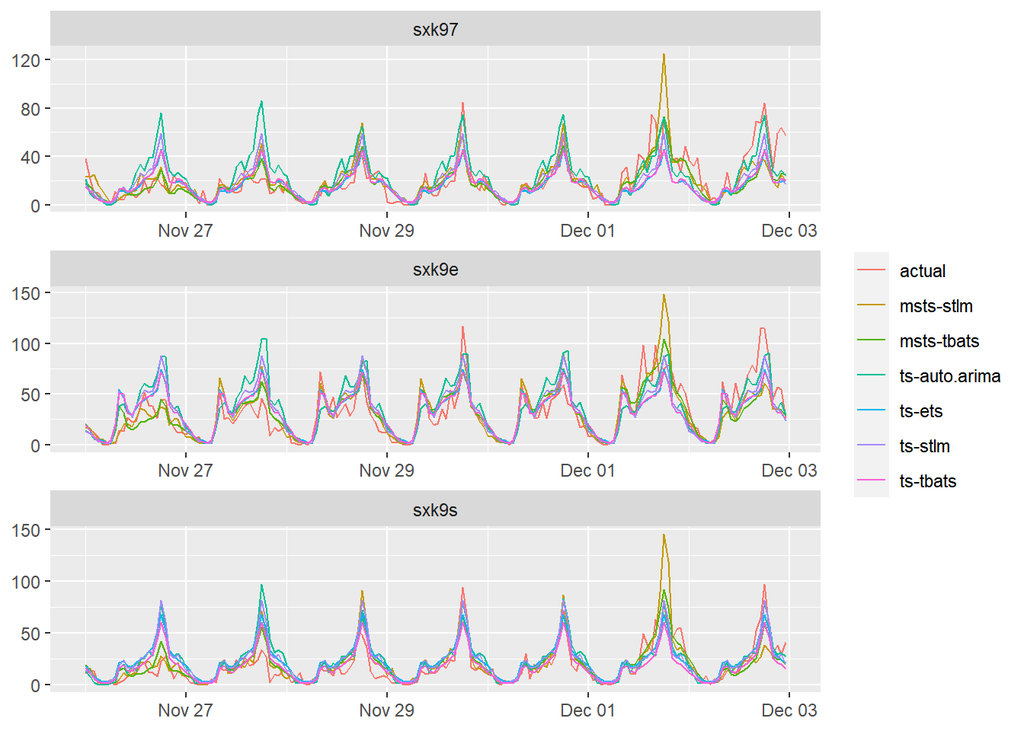

```r
df_test %>%
  ggplot(aes(x = start_time, y = n, colour = key)) +
    geom_line() +
    labs(x = NULL, y = NULL, colour = NULL) +
    facet_wrap(~ src_sub_area, scale = "free", ncol = 1)
```

## Automate The Model Selection

Berdasarkan plot yang telah kita lihat, seringkali sulit untuk kita memilih model mana yang tepat. Maka dari itu kita akan memilih model dengan error paling kecil.

```r
df_clean %<>%
  select(-fitted) %>% # remove unused
  group_by(src_sub_area) %>%
  filter(error == min(error)) %>%
  ungroup()
df_clean
```

```
## # A tibble: 3 x 8
##   src_sub_area test      train     data_fun_name data_fun model_name model error
##   <chr>        <list>    <list>    <chr>         <list>   <chr>      <lis> <dbl>
## 1 sxk97        <tibble ~ <tibble ~ msts          <fn>     tbats      <fn>  0.488
## 2 sxk9e        <tibble ~ <tibble ~ msts          <fn>     tbats      <fn>  0.359
## 3 sxk9s        <tibble ~ <tibble ~ msts          <fn>     stlm       <fn>  0.417
```

## Perform The Final Forecast

Proses yang dilakukan sama seperti saat melakukan model fitting, hanya saja kali ini kita akan menggunakan train dan test dataset secara penuh.

Pertama kita akan menggabungkan train dan test dataset.

```r
df_clean %<>%
  mutate(fulldata = map2(train, test, ~ bind_rows(.x, .y))) %>%
  select(src_sub_area, fulldata, everything(), -train, -test)
df_clean
```

```
## # A tibble: 3 x 7
##   src_sub_area fulldata            data_fun_name data_fun model_name model error
##   <chr>        <list>              <chr>         <list>   <chr>      <lis> <dbl>
## 1 sxk97        <tibble [1,512 x 2~ msts          <fn>     tbats      <fn>  0.488
## 2 sxk9e        <tibble [1,512 x 2~ msts          <fn>     tbats      <fn>  0.359
## 3 sxk9s        <tibble [1,512 x 2~ msts          <fn>     stlm       <fn>  0.417
```

lakukan nested fitting seperti sebelumnya.

```r
df_clean %<>%
  mutate(
    params = map(fulldata, ~ list(x = .x)),
    data = invoke_map(data_fun, params),
    params = map(data, ~ list(x = .x)),
    fitted = invoke_map(model, params)
  ) %>%
  select(-data, -params)
df_clean
```

```
## # A tibble: 3 x 8
##   src_sub_area fulldata     data_fun_name data_fun model_name model error fitted
##   <chr>        <list>       <chr>         <list>   <chr>      <lis> <dbl> <list>
## 1 sxk97        <tibble [1,~ msts          <fn>     tbats      <fn>  0.488 <tbat~
## 2 sxk9e        <tibble [1,~ msts          <fn>     tbats      <fn>  0.359 <tbat~
## 3 sxk9s        <tibble [1,~ msts          <fn>     stlm       <fn>  0.417 <stlm>
```

membuat tabel yang berisi hasil forecast dan convert nested data menjadi long format.

```r
df_clean %<>%
  mutate(forecast =
    map(fitted, ~ forecast(.x, h = 24 * 7)) %>%
    map2(fulldata, ~ tibble(
      start_time = timetk::tk_make_future_timeseries(.y$start_time, 24 * 7),
      n = as.vector(.x$mean)
    ))
  )
df_clean
```

```
## # A tibble: 3 x 9
##   src_sub_area fulldata     data_fun_name data_fun model_name model error fitted
##   <chr>        <list>       <chr>         <list>   <chr>      <lis> <dbl> <list>
## 1 sxk97        <tibble [1,~ msts          <fn>     tbats      <fn>  0.488 <tbat~
## 2 sxk9e        <tibble [1,~ msts          <fn>     tbats      <fn>  0.359 <tbat~
## 3 sxk9s        <tibble [1,~ msts          <fn>     stlm       <fn>  0.417 <stlm>
## # ... with 1 more variable: forecast <list>
```

## Assumption checking

Dalam time-series, asumsi yang harus kita cek adalah Non-autocorrelation on Residuals dan Normality of Residuals

```r
forecast1 <- df_clean$fitted[[1]]
forecast1 <- forecast(forecast1,h=24*7)
shapiro.test(forecast1$residuals)
```

```
##
##  Shapiro-Wilk normality test
##
## data:  forecast1$residuals
## W = 0.988, p-value = 7.544e-10
```

```r
Box.test(forecast1$residuals)
```

```
##
##  Box-Pierce test
##
## data:  forecast1$residuals
## X-squared = 0.007065, df = 1, p-value = 0.933
```

```r
forecast2 <- df_clean$fitted[[2]]
forecast2 <- forecast(forecast2,h=24*7)
shapiro.test(forecast2$residuals)
```

```
##
##  Shapiro-Wilk normality test
##
## data:  forecast2$residuals
## W = 0.99545, p-value = 0.0001571
```

```r
Box.test(forecast2$residuals)
```

```
##
##  Box-Pierce test
##
## data:  forecast2$residuals
## X-squared = 0.0011569, df = 1, p-value = 0.9729
```

```r
forecast3 <- df_clean$fitted[[3]]
forecast3 <- forecast(forecast3,h=24*7)
shapiro.test(forecast3$residuals)
```

```
##
##  Shapiro-Wilk normality test
##
## data:  forecast3$residuals
## W = 0.99537, p-value = 0.0001331
```

```r
Box.test(forecast3$residuals)
```

```
##
##  Box-Pierce test
##
## data:  forecast3$residuals
## X-squared = 13.203, df = 1, p-value = 0.0002794
```

Kita dapat melakukan unnest untuk mendapatkan hasil

```r
df_clean %<>%
  select(src_sub_area, actual = fulldata, forecast) %>%
  gather(key, value, -src_sub_area) %>%
  unnest(value) %>%
  mutate(n = rec_revert(n, rec, src_sub_area))
df_clean
```

```
## # A tibble: 5,040 x 4
##    src_sub_area key    start_time              n
##    <chr>        <chr>  <dttm>              <dbl>
##  1 sxk97        actual 2017-10-01 00:00:00     6
##  2 sxk97        actual 2017-10-01 01:00:00     4
##  3 sxk97        actual 2017-10-01 02:00:00     9
##  4 sxk97        actual 2017-10-01 03:00:00     2
##  5 sxk97        actual 2017-10-01 04:00:00     5
##  6 sxk97        actual 2017-10-01 05:00:00     4
##  7 sxk97        actual 2017-10-01 06:00:00     1
##  8 sxk97        actual 2017-10-01 07:00:00     0
##  9 sxk97        actual 2017-10-01 08:00:00     3
## 10 sxk97        actual 2017-10-01 09:00:00     3
## # ... with 5,030 more rows
```

Kita dapat melakukan plot untuk melihat hasil forecast

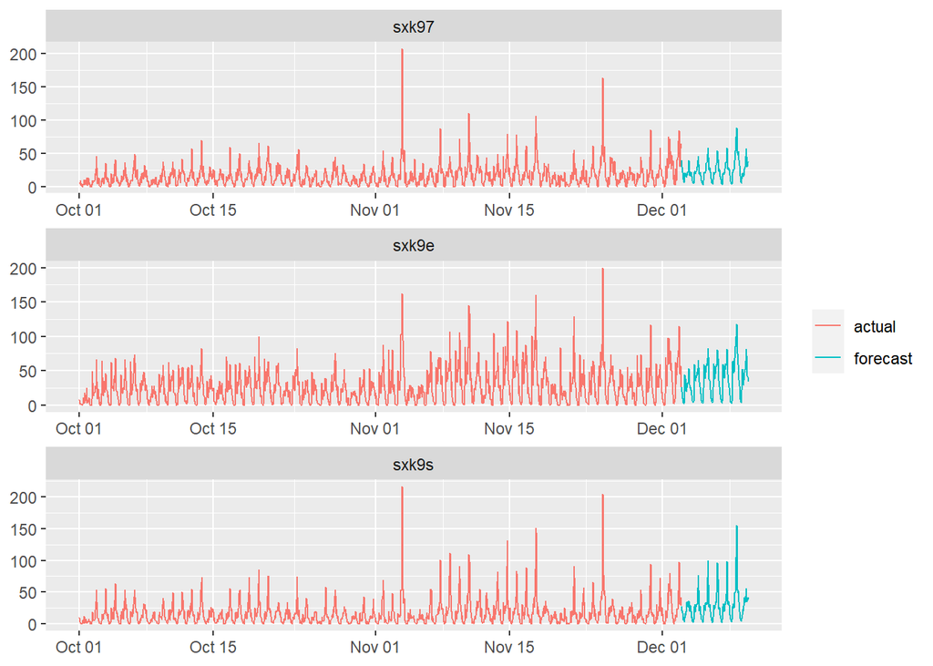

```r
df_clean %>%
  ggplot(aes(x = start_time, y = n, colour = key)) +
    geom_line() +
    labs(x = NULL, y = NULL, colour = NULL) +
    facet_wrap(~ src_sub_area, scale = "free", ncol = 1)
```

## Model Evaluataion 2

Kita akan melakukan model evaluation pada final model yang sudah melakukan forecast pada data test dengan menggunakan metrics MAE (Mean Absolute Error)

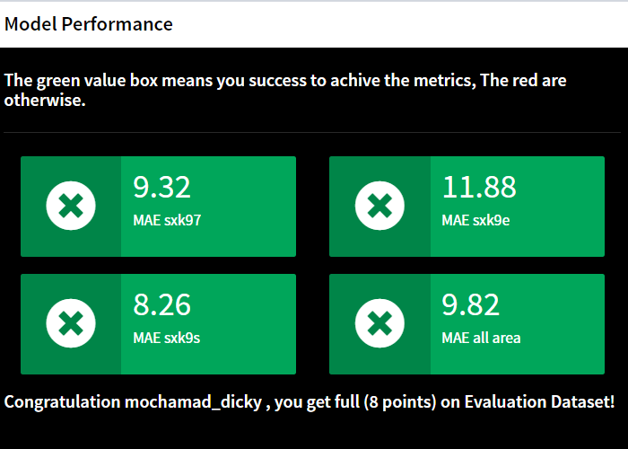

Model Evaluation 2